# Identity Encoding Code 09:

Introduced Range eBird Population Trends Over Time

[Grace Smith-Vidaurre](http://smith-vidaurre.com/)<sup>1-4*</sup> <sup>1</sup>Department of Biology, New Mexico State University <sup>2</sup>Laboratory of Neurogenetics of Language, Rockefeller University <sup>3</sup>Field Research Center, Rockefeller University <sup>4</sup>Department of Biological Sciences, University of Cincinnati *gsvidaurre@gmail.com

12 June, 2023

This code accompanies the following paper in PLOS Computational Biology:

Smith-Vidaurre, G., Perez-Marrufo, V., Hobson, E.A., Salinas-Melgoza, A., and T.F. Wright. 2023. Individual identity information persists in learned calls of introduced parrot populations.

See the methods and appendix of the associated publication for more information about these analyses, and these tips for [eBird best practices](https://cornelllabofornithology.github.io/ebird-best-practices/ebird.html).

Please cite the associated paper and code (see the DOI on GitHub) if these analyses are useful for your own research.

```r
rm(list = ls())

X <- c("tidyverse", "pbapply", "dplyr", "data.table", "parallel", "scales", "ggplot2", "auk", "pracma", "rgdal", "rgeos", "knitr")

invisible(lapply(X, library, character.only = TRUE))

# Suppress summarise warnings from dplyr
options(dplyr.summarise.inform = FALSE)

path <- "/media/gsvidaurre/MYIOPSITTA/R/VocalLearning_PostDisruption/Data"
tx_path <- file.path(path, "ebd_US-TX-453_200401_201912_relJul-2020") # path to Travis, TX eBird data
la_path <- file.path(path, "ebd_US-LA-071_200401_201912_relJul-2020") # path to New Orleans, LA eBird data

gpath <- "/media/gsvidaurre/MYIOPSITTA/R/VocalLearning_PostDisruption/Graphics"
seed <- 401
cores <- parallel::detectCores() - 2
```

Read in the extended selection table (EST). This contains metadata and wave objects for pre-processed native and introduced range calls across the individual and site scales.

```r
nat_int_est <- readRDS(file.path(path, "monk_parakeet_contactCalls_rangeComparison_extSelTable.RDS"))
# glimpse(nat_int_est)

# For which introduced range cities should we get eBird data?
nat_int_est %>%
  dplyr::filter(!is.na(introduced_city)) %>%
  pull(introduced_city) %>%
  unique() %>%
  as.character()
```

```
## [1] "Austin"      "New Orleans" "El Paso"     "Dallas"      "Gilbert"
## [6] "Milford"     "Stratford"   "Miami"
```

# eBird downloads

After getting eBird access, I downloaded data on 16 September 2020 for the following counties in the USA:

- Travis, TX (for Austin, all species)
- Dallas, TX
- Orleans, LA (for New Orleans, all species)
- Miami-Dade, FL (for Miami)
- Fairfield, CT (for Stratford)
- New Haven, CT (for Milford)

Unless otherwise noted, the search was limited to *Myiopsitta monachus*. For Austin and New Orleans, all species were requested so as to evaluate monk parakeet frequency in checklists relative to other species over time. The date range for all requests was January 2004 - January 2020. No unvetted data was included. I did not download data for El Paso, TX (only a single bird and nest), and Gilbert, AZ (3 birds, 2 nests). For the purposes of this manuscript, analyses below were limited to Austin, TX and New Orleans, LA to assess population trends over time.

```r
# Austin, from Travis county
ebd_aust_mnk <- read_ebd(file.path(file.path(path, "ebd_US-TX-453_200401_202001_relAug-2020"), "ebd_US-TX-453_200401_202001_relAug-2020.txt")) %>%
  dplyr::filter(grepl("Austin", locality, ignore.case = TRUE)) %>%
  # Get just monk parakeets
  dplyr::filter(grepl("Myiopsitta", scientific_name, ignore.case = TRUE)) %>%
  droplevels()

saveRDS(ebd_aust_mnk, file.path(path, "ebd_aust_mnk.RDS"))

# New Orleans, from Orleans county
ebd_norl_mnk <- read_ebd(file.path(file.path(path, "ebd_US-LA-071_200401_202001_relAug-2020"), "ebd_US-LA-071_200401_202001_relAug-2020.txt")) %>%
  dplyr::filter(grepl("New Orleans", locality, ignore.case = TRUE)) %>%
  # Get just monk parakeets
  dplyr::filter(grepl("Myiopsitta", scientific_name, ignore.case = TRUE)) %>%
  droplevels()

saveRDS(ebd_norl_mnk, file.path(path, "ebd_norl_mnk.RDS"))
```

Checking that the monk parakeet observations looked ok for assessing population trends.

```r
ebd_aust_mnk <- readRDS(file.path(path, "ebd_aust_mnk.RDS"))
dim(ebd_aust_mnk) # 3521 monk parakeet observations
names(ebd_aust_mnk)

ebd_norl_mnk <- readRDS(file.path(path, "ebd_norl_mnk.RDS"))
dim(ebd_norl_mnk) # 500 monk parakeet observations

# Are all scientific names ok? Looks good
ebd_aust_mnk %>%
  pull(scientific_name) %>%
  unique()

ebd_norl_mnk %>%
  pull(scientific_name) %>%
  unique()

# Does each row represent a unique checklist? Yes, looks good
ebd_aust_mnk %>%
  pull(checklist_id) %>%
  duplicated() %>%
  any()

ebd_norl_mnk %>%
  pull(checklist_id) %>%
  duplicated() %>%
  any()

# Is the year range correct? Also looks good
ebd_aust_mnk %>%
  dplyr::mutate(
    observation_date = as.character(observation_date)
  ) %>%
  dplyr::select(observation_date) %>%
  tidyr::separate(observation_date, into = c("year", "month", "day"), sep = "-") %>%
  pull(year) %>%
  unique()

ebd_norl_mnk %>%
  dplyr::mutate(
    observation_date = as.character(observation_date)
  ) %>%
  dplyr::select(observation_date) %>%
  tidyr::separate(observation_date, into = c("year", "month", "day"), sep = "-") %>%
  pull(year) %>%
  unique()

# For the analyses below we did not take observation counts or the numbers of parakeets reported per checklist
# Checked out observations with the highest counts recorded, along with species comments
# ebd_aust_mnk %>%
#   dplyr::filter(observation_count > 10) %>%
#   dplyr::mutate(observation_count = as.numeric(observation_count)) %>%
#   dplyr::filter(observation_count > 10) %>%
#   dplyr::select(observation_count, species_comments) %>%
#   dplyr::filter(complete.cases(species_comments)) %>%
#   View()

# ebd_norl_mnk %>%
#   dplyr::filter(observation_count != "X") %>%
#   dplyr::mutate(observation_count = as.numeric(observation_count)) %>%
#   dplyr::filter(observation_count > 10) %>%
#   dplyr::select(observation_count, species_comments) %>%
#   dplyr::filter(complete.cases(species_comments)) %>%
#   View()
```

# Averaging checklists by sampling year

## Austin

I binned checklists by weeks per year then calculated the percentage of parakeet sightings relative to other species across these bins, following an approach used by Clark (2017)<sup>[1]</sup>. Here I used the eBird checklists with all species to calculate the frequency of monk parakeet observations relative to other species.

```r
ebd_aust <- read_ebd(file.path(file.path(path, "ebd_US-TX-453_200401_202001_relAug-2020"), "ebd_US-TX-453_200401_202001_relAug-2020.txt")) %>%
  dplyr::filter(grepl("Austin", locality, ignore.case = TRUE)) %>%
  # Retain just checklists for which all species reported
  dplyr::filter(all_species_reported)

# Check that scientific names are reasonable values, looks good
ebd_aust %>%
  pull(scientific_name) %>%
  unique()

# Get the frequency of monk parakeet sightings in complete checklists relative to all species in checklists
ebd_aust_perc <- ebd_aust %>%
  # Per week across years, get the percentage of checklists that reported monk parakeets, regardless of whether group size was recorded
  # Add years, weeks
  dplyr::mutate(
    week = week(observation_date),
    year = year(observation_date)
  ) %>%
  dplyr::select(checklist_id, state, locality, observation_date, observation_count, week, year, scientific_name) %>%
  group_by(week, year) %>%
  dplyr::summarise(
    mnk_checklist_obs = length(grep("Myiopsitta", scientific_name)),
    all_species_checklist_obs = length(scientific_name),
    perc_mnks = (length(grep("Myiopsitta", scientific_name))/length(scientific_name))*100
  ) %>%
  ungroup()

glimpse(ebd_aust_perc)

# Checking the distribution of the number of parakeet sightings when binning by week
ebd_aust_perc %>%
  pull(mnk_checklist_obs) %>%
  table()

# 244 weeks with 0 sightings; 96 weeks with 1 sighting; 61 weeks with 2 sightings, and so on
# 0   1   2   3   4   5   6   7   8   9  10  11  12  13
# 244  96  61  55  42  50  44  29  38  21  21  24  15   4
#  14  15  16  17  18  20  21  24
#   4   7   1   2   2   1   1   1

saveRDS(ebd_aust_perc, file.path(path, "ebd_aust_perc.RDS"))
```

### Weekly population trends in 2004, 2011, 2019

```r
ebd_aust_perc <- readRDS(file.path(path, "ebd_aust_perc.RDS"))
glimpse(ebd_aust_perc)
```

```
## Rows: 763
## Columns: 5
## $ week                      <int> 1, 1, 1, 1, 1, 1, 1, 1, 1, 1, 1, 1, 1, 1, 1,…
## $ year                      <int> 2004, 2005, 2006, 2007, 2008, 2009, 2010, 20…
## $ mnk_checklist_obs         <int> 0, 0, 1, 1, 0, 0, 1, 1, 3, 12, 9, 8, 15, 5, …
## $ all_species_checklist_obs <int> 2, 11, 9, 23, 30, 45, 60, 185, 176, 833, 739…
## $ perc_mnks                 <dbl> 0.0000000, 0.0000000, 11.1111111, 4.3478261,…
```

```r
# Get weekly checklist percentages for our sampling years in Austin
ebd_aust_w <- ebd_aust_perc %>%
  dplyr::filter(year %in% c(2004, 2011, 2019)) %>%
  droplevels() %>%
  dplyr::mutate(
    year = as.character(year),
    year = factor(year)
  ) %>%
  droplevels() %>%
  ungroup()

glimpse(ebd_aust_w)
```

```
## Rows: 134
## Columns: 5
## $ week                      <int> 1, 1, 1, 2, 2, 2, 3, 3, 3, 4, 4, 4, 5, 5, 5,…
## $ year                      <fct> 2004, 2011, 2019, 2004, 2011, 2019, 2004, 20…
## $ mnk_checklist_obs         <int> 0, 1, 12, 0, 2, 8, 0, 0, 11, 1, 3, 14, 0, 1,…
## $ all_species_checklist_obs <int> 2, 185, 680, 2, 233, 711, 14, 93, 813, 66, 2…
## $ perc_mnks                 <dbl> 0.0000000, 0.5405405, 1.7647059, 0.0000000, …
```

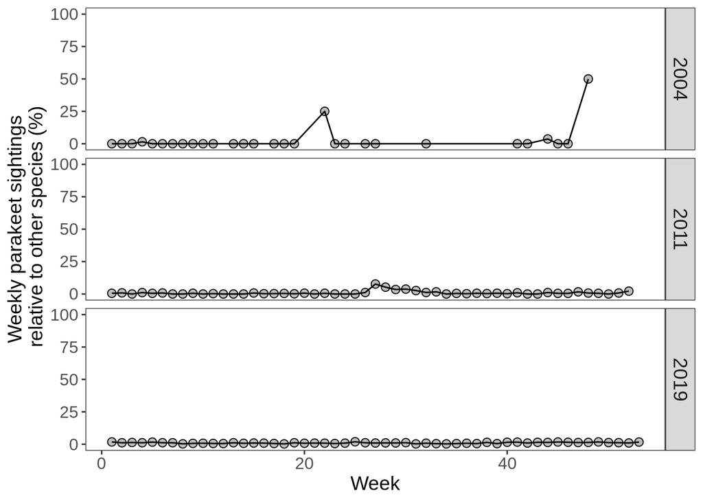

```r
ebd_aust_w %>%
  ggplot(aes(x = week, y = perc_mnks), color = "black") +
  geom_point(shape = 21, size = 2.5, fill = "grey") +
  geom_line() +
  facet_grid(rows = vars(year)) +
  xlab("Week") +
  ylab("Weekly parakeet sightings\n relative to other species (%)") +
  scale_y_continuous(limits = c(0, 100)) +
  theme_bw() +
  theme(
    panel.grid.major = element_blank(),
    panel.grid.minor = element_blank(),
    axis.title = element_text(size = 14),
    axis.text = element_text(size = 12),
    strip.text = element_text(size = 14)
  )
```

Some weeks in 2004 had high percentages of parakeets reported in checklists compared to other species. I checked out these weeks to determine whether these percentages were due to many sightings of monk parakeets or rather few species reported in total.

```r
# Check larger weekly percentages reported across years
ebd_aust_perc %>%
  dplyr::filter(perc_mnks > 10) %>%
  kable(align = rep("c", ncol(.)))

# A median of only 4 sightings of all species total were reported when weekly percentages were high for parakeets
ebd_aust_perc %>%
  dplyr::filter(perc_mnks > 10) %>%
  pull(all_species_checklist_obs) %>%
  median()

# The median total sightings of all species reported per checklist across this dataset was 301
ebd_aust_perc %>%
  pull(all_species_checklist_obs) %>%
  median()
```

These larger weekly percentages (> 10%) are likely due to observers reporting few species overall in these checklists. When the weekly percentages of relative monk parakeet sightings were high, the median of total sightings was two orders of magnitude lower (4 total species) than the full dataset (301 total species).

## New Orleans

```r
ebd_norl <- read_ebd(file.path(file.path(path, "ebd_US-LA-071_200401_202001_relAug-2020"), "ebd_US-LA-071_200401_202001_relAug-2020.txt")) %>%
  dplyr::filter(grepl("New Orleans", locality, ignore.case = TRUE)) %>%
  dplyr::filter(all_species_reported)

# Check that scientific names have reasonable strings
ebd_norl %>%
  pull(scientific_name) %>%
  unique()

# Get frequencies of monk parakeet sightings across sampling years as for Austin TX
ebd_norl_perc <- ebd_norl %>% # Retain just checklists for which all species reported
  # Per week across years, get the proportion of checklists that reported monk parakeets, regardless of whether group size was recorded
  # Add years, weeks
  dplyr::mutate(
    week = week(observation_date),
    year = year(observation_date)
  ) %>%
  dplyr::select(checklist_id, state, locality, observation_date, observation_count, week, year, scientific_name) %>%
  group_by(week, year) %>%
  dplyr::summarise(
    mnk_checklist_obs = length(grep("Myiopsitta", scientific_name)),
    all_species_checklist_obs = length(scientific_name),
    perc_mnks = (length(grep("Myiopsitta", scientific_name))/length(scientific_name))*100
  ) %>%
  ungroup()

glimpse(ebd_norl_perc)

# Checking the distribution of the number of parakeet sightings when binning by week
ebd_norl_perc %>%
  pull(mnk_checklist_obs) %>%
  table()

# 299 weeks with 0 sightings; 162 weeks with 1 sighting; 43 weeks with 2 sightings, and so on
# 0   1   2   3   4   5   6   7
# 299 162  43  22   4   2   1   1

saveRDS(ebd_norl_perc, file.path(path, "ebd_norl_perc.RDS"))
```

### Weekly population trends in 2004, 2011, 2019

```r
ebd_norl_perc <- readRDS(file.path(path, "ebd_norl_perc.RDS"))
# glimpse(ebd_norl_perc)

# Weekly checklist frequency across weeks per year, as a percentage
ebd_norl_w <- ebd_norl_perc %>%
  dplyr::filter(year %in% c(2004, 2011, 2019)) %>%
  droplevels() %>%
  dplyr::mutate(
    year = as.character(year),
    year = factor(year)
  ) %>%
  droplevels() %>%
  ungroup()

# glimpse(ebd_norl_w)

# Not all weeks had observations per year
# 2004 had fewer checklists
ebd_norl_w %>%
  group_by(year) %>%
  dplyr::summarise(n = n())
```

```
## # A tibble: 3 × 2
##   year      n
##   <fct> <int>
## 1 2004      6
## 2 2011     33
## 3 2019     53
```

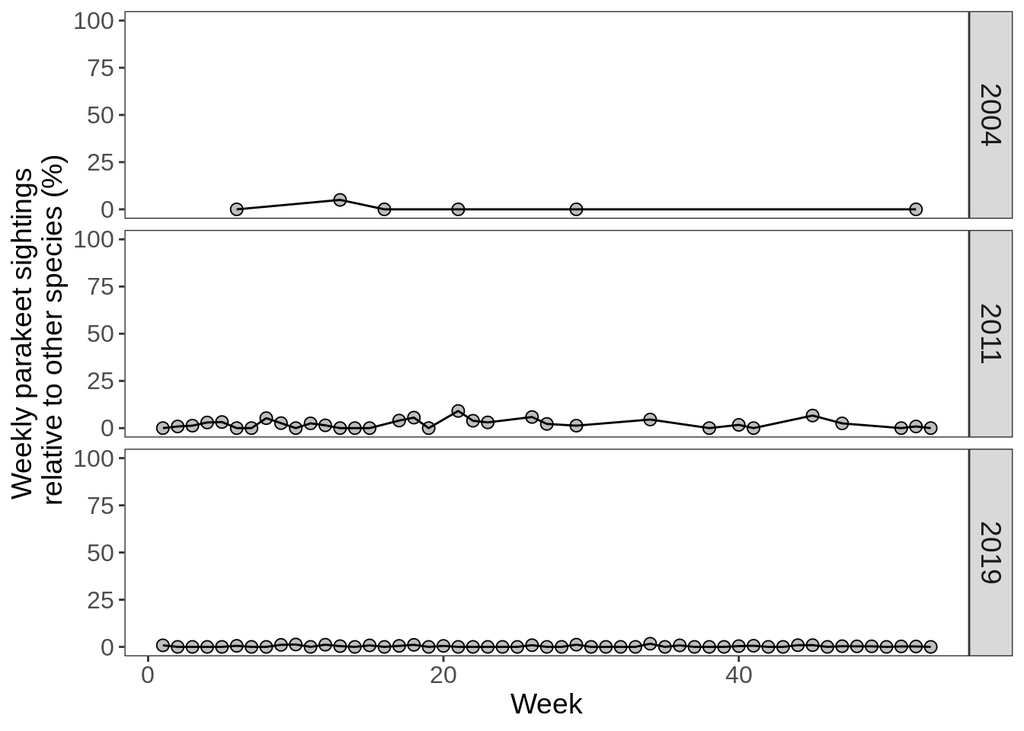

```r
ebd_norl_w %>%
  ggplot(aes(x = week, y = perc_mnks), color = "black") +
  geom_point(shape = 21, size = 2.5, fill = "grey") +
  geom_line() +
  facet_grid(rows = vars(year)) +
  xlab("Week") +
  ylab("Weekly parakeet sightings\n relative to other species (%)") +
  scale_y_continuous(limits = c(0, 100)) +
  theme_bw() +
  theme(
    panel.grid.major = element_blank(),
    panel.grid.minor = element_blank(),
    axis.title = element_text(size = 14),
    axis.text = element_text(size = 12),
    strip.text = element_text(size = 14)
  )
```

# Checklist percentages across years

Here I averaged the weekly percentages of parakeet sightings (relative to other species) by year for Austin and New Orleans. I performed this summary across the span of time represented by our sampling years (2004 to 2019). This plot was used as a main figure in the accompanying article.

```r
ebd_aust_perc <- readRDS(file.path(path, "ebd_aust_perc.RDS"))
# glimpse(ebd_aust_perc)

ebd_norl_perc <- readRDS(file.path(path, "ebd_norl_perc.RDS"))
# glimpse(ebd_norl_perc)

# Average weekly checklist frequency by year, as a percentage
ebd_aust_norl <- ebd_aust_perc %>%
  dplyr::mutate(
    city = "Austin"
  ) %>%
  bind_rows(
    ebd_norl_perc %>%
      dplyr::mutate(
        city = "New Orleans"
      )
  ) %>%
  dplyr::mutate(
    year = as.character(year),
    year = factor(year)
  ) %>%
  group_by(city, year) %>%
  dplyr::summarise(
    yr_avg = mean(perc_mnks),
    yr_sd = sd(perc_mnks)
  ) %>%
  ungroup()

glimpse(ebd_aust_norl)
```

```
## Rows: 34
## Columns: 4
## $ city   <chr> "Austin", "Austin", "Austin", "Austin", "Austin", "Austin", "Au…
## $ year   <fct> 2004, 2005, 2006, 2007, 2008, 2009, 2010, 2011, 2012, 2013, 201…
## $ yr_avg <dbl> 2.7661674, 0.4777831, 1.9656798, 2.1766379, 0.7208076, 0.497899…
## $ yr_sd  <dbl> 10.2104889, 1.6591748, 6.7354755, 6.4115058, 1.5393190, 1.51924…
```

```r
# Range of percentages of relative monk parakeet sightings across years and cities
range(ebd_aust_norl$yr_avg)
```

```
## [1] 0.000000 3.707116
```

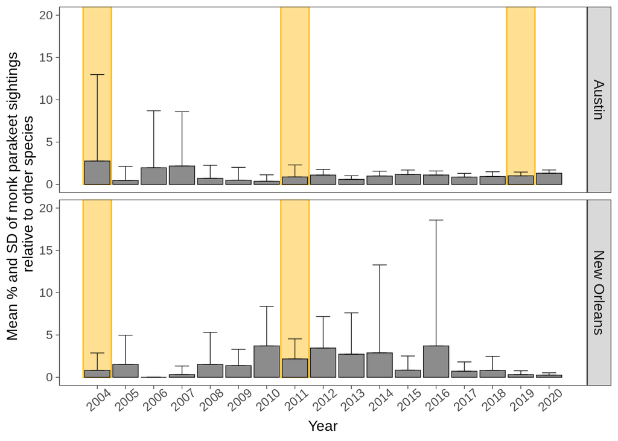

```r
# Make a data frame of year coordinates for adding rectangles
rect_df <- data.frame(
  year_xmin = c(2003.5, 2010.5, 2018.5, 2003.5, 2010.5),
  year_xmax = c(2004.5, 2011.5, 2019.5, 2004.5, 2011.5),
  city = c(rep("Austin", 3), rep("New Orleans", 2))
)

ebd_aust_norl %>%
  # Convert years to numeric to add rectangles below
  dplyr::mutate(
    year = as.numeric(as.character(year))
  ) %>%
  ggplot(aes(x = year, y = yr_avg), color = "black") +
  # Add shaded rectangles for years recorded per city
  geom_rect(data = rect_df, aes(xmin = year_xmin, xmax = year_xmax, ymin = 0, ymax = Inf), color = alpha("darkgoldenrod1", 1), fill = alpha("darkgoldenrod1", 0.45), inherit.aes = FALSE) +
  geom_col(fill = "gray55", color = "black", size = 0.25) +
  geom_errorbar(aes(ymin = yr_avg, ymax = yr_avg + yr_sd), color = "black", size = 0.25, width = 0.5) +
  facet_grid(rows = vars(city)) +
  scale_x_continuous(limits = c(2003.5, 2020.5), breaks = seq(2004, 2020, 1), labels = seq(2004, 2020, 1)) +
  scale_y_continuous(limits = c(0, 20)) +
  xlab("Year") +
  ylab("Mean % and SD of monk parakeet sightings\n relative to other species") +
  theme_bw() +
  theme(
    axis.ticks = element_line(size = 0.25),
    axis.title = element_text(size = 12),
    axis.text.y = element_text(size = 10),
    axis.text.x = element_text(size = 10, angle = 40, vjust = 0.75),
    strip.text = element_text(size = 12),
    panel.grid.major = element_blank(),
    panel.grid.minor = element_blank()
  )
```

```r
# ggsave(file.path(gpath, "HierarchicalMapping_eBirdAustinNewOrl_PopTrends.jpeg"), units = "in", width = 6.5, height = 5, dpi = 300)
```

# References

```
1. Clark, C.J. 2017. eBird records show substantial growth of the Allen’s Hummingbird (Selasphorus sasin sedentarius) population in urban Southern California. The Condor, 119(1), 122–130. https://doi.org/10.1650/condor-16-153.1
```